# Final_Suryansh_CJ

The goal of the Project is to find the majors that have the best salaries. Should you do Engineering or Math or Economics or maybe Graphic Design? Choosing a college major is a big task. Students must choose a course of study that will challenge and fascinate them while balancing the harsh realities of the labor market and career prospects. A high starting income is essential for a stable middle-class future, and with rising student loan obligations, picking a major that pays well right away becomes even more appealing.

```r
# Loading all the packages
library(tidyverse)
library(cluster)
library(factoextra)
#Loading the file
data <- read_csv('degrees-and-pay.csv', col_types = cols())

head(data)
```

```
## # A tibble: 6 × 8
##   `Undergraduate Major` `Starting Median… `Mid-Career Media… `Percent change fr…
##   <chr>                 <chr>             <chr>                            <dbl>
## 1 Accounting            $46,000.00        $77,100.00                        67.6
## 2 Aerospace Engineering $57,700.00        $101,000.00                       75
## 3 Agriculture           $42,600.00        $71,900.00                        68.8
## 4 Anthropology          $36,800.00        $61,500.00                        67.1
## 5 Architecture          $41,600.00        $76,800.00                        84.6
## 6 Art History           $35,800.00        $64,900.00                        81.3
## # … with 4 more variables: Mid-Career 10th Percentile Salary <chr>,
## #   Mid-Career 25th Percentile Salary <chr>,
## #   Mid-Career 75th Percentile Salary <chr>,
## #   Mid-Career 90th Percentile Salary <chr>
```

```r
sapply(data, class)
```

```
##                               Undergraduate Major
##                                       "character"
##                            Starting Median Salary
##                                       "character"
##                          Mid-Career Median Salary
##                                       "character"
## Percent change from Starting to Mid-Career Salary
##                                         "numeric"
##                 Mid-Career 10th Percentile Salary
##                                       "character"
##                 Mid-Career 25th Percentile Salary
##                                       "character"
##                 Mid-Career 75th Percentile Salary
##                                       "character"
##                 Mid-Career 90th Percentile Salary
##                                       "character"
```

```r
#Changing names for easy access
colnames(data) <- c('Subject','Starting_Median_Salary','Mid_Career_Median_Salary','Career_Percent_Growth',
                  'Percentile_is_10','Percentile_is_25','Percentile_is_75','Percentile_is_90')

majors = data['Subject']

#Removing all the special characters
salaries <- data %>%
    select(-Subject) %>%
    mutate_all(function(x) as.numeric(gsub("[\\$,]","",x))) %>%
    mutate(Career_Percent_Growth = Career_Percent_Growth/100)

data = bind_cols(majors,salaries)

head(data)
```

```
## # A tibble: 6 × 8
##   Subject   Starting_Median_… Mid_Career_Medi… Career_Percent_… Percentile_is_10
##   <chr>                 <dbl>            <dbl>            <dbl>            <dbl>
## 1 Accounti…             46000            77100            0.676            42200
## 2 Aerospac…             57700           101000            0.75             64300
## 3 Agricult…             42600            71900            0.688            36300
## 4 Anthropo…             36800            61500            0.671            33800
## 5 Architec…             41600            76800            0.846            50600
## 6 Art Hist…             35800            64900            0.813            28800
## # … with 3 more variables: Percentile_is_25 <dbl>, Percentile_is_75 <dbl>,
## #   Percentile_is_90 <dbl>
```

```r
sapply(data,class)
```

```
##                  Subject   Starting_Median_Salary Mid_Career_Median_Salary
##              "character"                "numeric"                "numeric"
##    Career_Percent_Growth         Percentile_is_10         Percentile_is_25
##                "numeric"                "numeric"                "numeric"
##         Percentile_is_75         Percentile_is_90
##                "numeric"                "numeric"
```

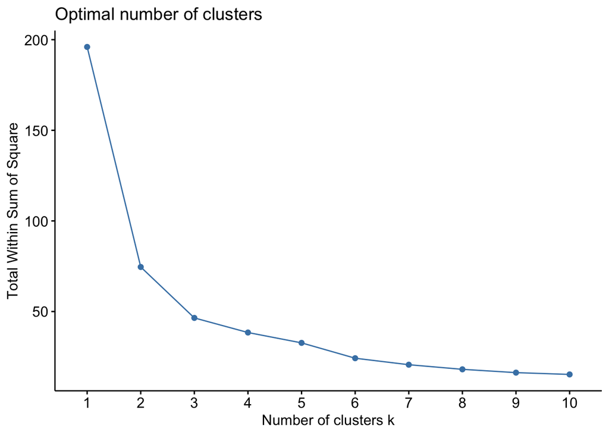

```r
#basing our clusters
data_for_kmeans <- data %>%
    select(Starting_Median_Salary, Mid_Career_Median_Salary, Percentile_is_10, Percentile_is_90) %>%
    scale()

#Elbow Method
set.seed(7)
max_no_of_k <- 15
wss <- sapply(1:max_no_of_k, function(k){kmeans(data_for_kmeans, k, nstart=25, iter.max = 15)$tot.withinss})

clust = as.data.frame(wss)
clust$k = 1:nrow(clust)

fviz_nbclust(data_for_kmeans, kmeans, method = "wss")
```

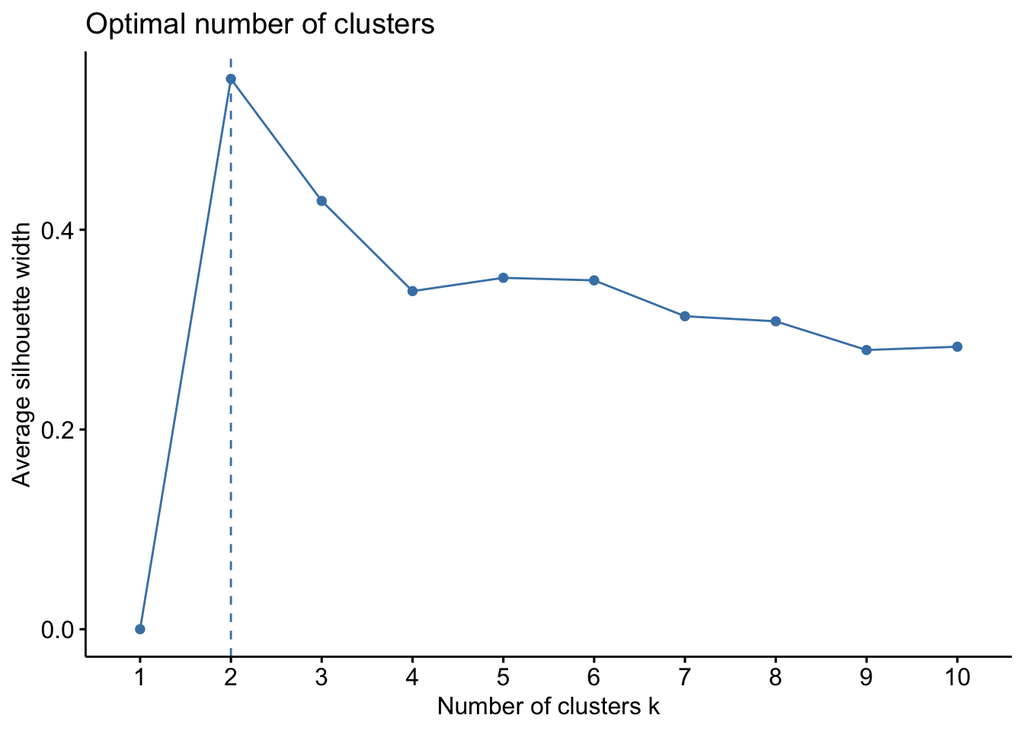

```r
#Silhouette Method
fviz_nbclust(data_for_kmeans, kmeans, method = "silhouette")
```